# FI 362 — Day 1 Supplement

# 6 Portfolio returns

> *Slides: “Portfolio Return”.* Simple returns aggregate **exactly** across assets, $R_{p,t}=\sum_i w_i R_{i,t}$; log returns aggregate only **approximately**, $r_{p,t}\approx\sum_i w_i r_{i,t}$.

Build an equal-weight portfolio of the five US stocks and compare the *exact* simple-return aggregation with the *log* approximation.

```r
px  <- stocks[, c("AAPL","MSFT","AXP","CAT","SBUX")]
Rs  <- as.data.frame(lapply(px, function(p) simple_ret(p)))   # simple returns
rs  <- as.data.frame(lapply(px, function(p) log_ret(p)))       # log returns
wts <- rep(1/5, 5)                                  # equal weights

Rp        <- as.numeric(as.matrix(Rs) %*% wts)      # exact portfolio simple return
rp_exact  <- log(1 + Rp)                            # its true log return
rp_approx <- as.numeric(as.matrix(rs) %*% wts)      # weighted-average log return

cmp <- na.omit(data.frame(rp_exact = 100*rp_exact, rp_approx = 100*rp_approx))
cat(sprintf("Correlation(exact, approx) = %.6f;  max abs error = %.4f %%-pts\n",
            cor(cmp$rp_exact, cmp$rp_approx), max(abs(cmp$rp_exact - cmp$rp_approx))))
```

```
Correlation(exact, approx) = 0.999563;  max abs error = 3.4145 %-pts
```

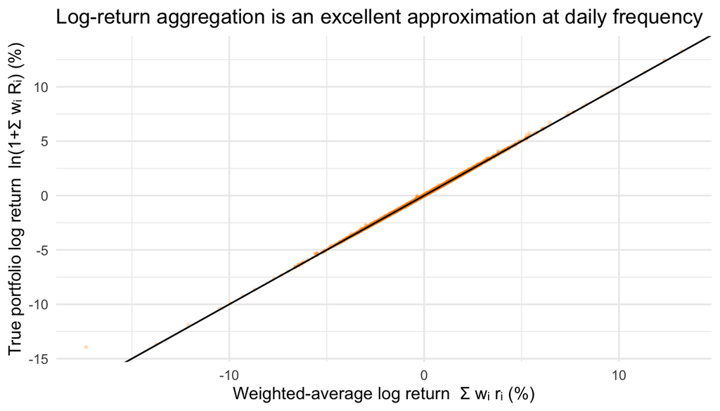

```r
ggplot(cmp, aes(rp_approx, rp_exact)) +
  geom_point(alpha = 0.2, size = 0.6, colour = "darkorange") +
  geom_abline(slope = 1, intercept = 0, colour = "black") +
  labs(x = "Weighted-average log return  Σ wᵢ rᵢ (%)",
       y = "True portfolio log return  ln(1+Σ wᵢ Rᵢ) (%)",
       title = "Log-return aggregation is an excellent approximation at daily frequency")
```

# 7 Distributional properties of returns

> *Slides: “Variance, Skewness, Kurtosis” → “Moments of a Random Sample”.* Mean, sd, skewness, and **excess** kurtosis ($\mathcal K - 3$).

We compute the four sample moments (in % per day) for every series, using the exact slide formulas. Note the **near-universal positive excess kurtosis** (fat tails) and **negative skewness** of equity returns.

```r
all_px <- cbind(indices[ , -1], stocks[match(indices$Date, stocks$Date), -1])
ret_pct <- lapply(all_px, function(p) 100 * log_ret(p))   # % log returns

tab <- do.call(rbind, lapply(names(ret_pct), function(nm) {
  s <- samp_stats(ret_pct[[nm]]); cbind(Series = nm, s)
}))
rownames(tab) <- NULL
kable(tab, digits = 3,
      caption = "Sample moments of daily % log returns (mean, sd, skew, excess kurtosis, min, max).")
```

Sample moments of daily % log returns (mean, sd, skew, excess kurtosis, min, max).

| Series | n | mean | sd | skew | exkurt | min | max |
| --- | --- | --- | --- | --- | --- | --- | --- |
| SP500 | 6388 | 0.028 | 1.217 | -0.343 | 10.895 | -12.765 | 10.957 |
| NASDAQ | 6388 | 0.032 | 1.557 | -0.097 | 6.524 | -13.149 | 13.255 |
| DowJones | 6388 | 0.025 | 1.154 | -0.321 | 13.157 | -13.842 | 10.764 |
| FTSE100 | 6498 | 0.004 | 1.130 | -0.371 | 8.540 | -11.512 | 9.384 |
| DAX | 6580 | 0.015 | 1.410 | -0.172 | 6.124 | -13.055 | 10.797 |
| CAC40 | 6645 | 0.002 | 1.370 | -0.212 | 6.721 | -13.098 | 10.595 |
| Nikkei225 | 6138 | 0.006 | 1.439 | -0.574 | 6.818 | -13.234 | 9.737 |
| HangSeng | 6209 | 0.000 | 1.450 | -0.051 | 7.147 | -13.582 | 13.407 |
| SSEComposite | 6221 | 0.012 | 1.425 | -0.339 | 5.679 | -9.256 | 9.401 |
| KOSPI | 6209 | 0.032 | 1.463 | -0.594 | 8.098 | -12.849 | 11.284 |
| Sensex | 6143 | 0.033 | 1.352 | -0.461 | 10.583 | -14.102 | 15.990 |
| AAPL | 6388 | 0.088 | 2.505 | -4.034 | 117.736 | -73.125 | 14.262 |
| MSFT | 6388 | 0.045 | 1.889 | -0.045 | 8.687 | -15.945 | 17.869 |
| AXP | 6388 | 0.038 | 2.217 | 0.187 | 11.629 | -19.352 | 19.789 |
| CAT | 6388 | 0.069 | 2.027 | -0.093 | 4.587 | -15.686 | 13.735 |
| SBUX | 6388 | 0.057 | 2.109 | 0.163 | 9.905 | -20.363 | 21.911 |

# 8 The stylised facts (what the slides assert, made visible)

> *Slide: “Why i.i.d. normal is unrealistic”* lists volatility clustering, fat tails, skewness, and serial dependence — here they are, on the S&P 500.

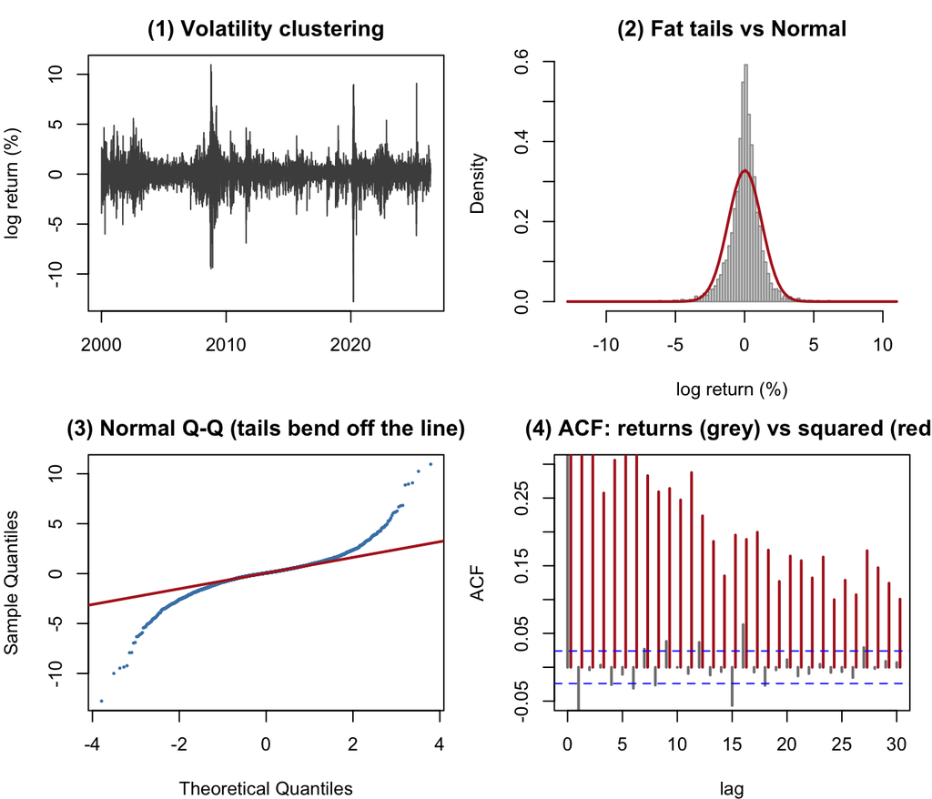

```r
r <- 100 * na.omit(sp$r)
dts <- sp$Date[is.finite(sp$r)]

op <- par(mfrow = c(2, 2), mar = c(4, 4, 2.5, 1))

## (1) Volatility clustering: big moves cluster in time
plot(dts, r, type = "l", col = "grey30", xlab = "", ylab = "log return (%)",
     main = "(1) Volatility clustering")

## (2) Fat tails / skew: histogram with fitted Normal overlay
hist(r, breaks = 120, freq = FALSE, col = "grey85", border = "grey60",
     xlab = "log return (%)", main = "(2) Fat tails vs Normal")
curve(dnorm(x, mean(r), sd(r)), add = TRUE, col = "firebrick", lwd = 2)

## (3) Normal QQ-plot: departures in the tails
qqnorm(r, pch = 16, cex = 0.4, col = "steelblue",
       main = "(3) Normal Q-Q (tails bend off the line)")
qqline(r, col = "firebrick", lwd = 2)

## (4) Serial dependence: ACF of returns vs squared returns
a1 <- acf(r,   lag.max = 30, plot = FALSE)
a2 <- acf(r^2, lag.max = 30, plot = FALSE)
plot(a1$lag, a1$acf, type = "h", lwd = 2, col = "grey50", ylim = c(-0.05, 0.3),
     xlab = "lag", ylab = "ACF", main = "(4) ACF: returns (grey) vs squared (red)")
lines(a2$lag + 0.3, a2$acf, type = "h", lwd = 2, col = "firebrick")
abline(h = c(-1.96, 1.96)/sqrt(length(r)), lty = 2, col = "blue")
```

```r
par(op)
```

Read-off: returns themselves are almost serially uncorrelated (grey, panel 4), but **squared** returns are strongly autocorrelated (red) — volatility is predictable even when the direction is not. This is the empirical seed of the ARCH/GARCH models in later chapters.

# 9 Testing normality

> *Slides: “Testing Skewness and Kurtosis” + “Jarque–Bera Test”.* Under normality $\hat{\mathcal S}\sim N(0,6/T)$, $\hat{\mathcal K}-3\sim N(0,24/T)$, and $\mathrm{JB}=\frac{\hat{\mathcal S}^2}{6/T}+\frac{(\hat{\mathcal K}-3)^2}{24/T}\to\chi^2_2$.

```r
jb <- do.call(rbind, lapply(names(ret_pct), function(nm)
  cbind(Series = nm, norm_tests(ret_pct[[nm]]))))
rownames(jb) <- NULL
kable(jb, digits = c(0,3,2,4,3,2,4,1,4),
      caption = "Skewness, excess-kurtosis and Jarque–Bera tests (p ≈ 0 ⇒ reject normality).")
```

Skewness, excess-kurtosis and Jarque–Bera tests (p ≈ 0 ⇒ reject normality).

| Series | skew | t_skew | p_skew | exkurt | t_kurt | p_kurt | JB | p_JB |
| --- | --- | --- | --- | --- | --- | --- | --- | --- |
| SP500 | -0.343 | -11.18 | 0.0000 | 10.895 | 177.75 | 0 | 31719.4 | 0 |
| NASDAQ | -0.097 | -3.18 | 0.0015 | 6.524 | 106.43 | 0 | 11337.3 | 0 |
| DowJones | -0.321 | -10.46 | 0.0000 | 13.157 | 214.65 | 0 | 46182.4 | 0 |
| FTSE100 | -0.371 | -12.22 | 0.0000 | 8.540 | 140.52 | 0 | 19894.2 | 0 |
| DAX | -0.172 | -5.68 | 0.0000 | 6.124 | 101.39 | 0 | 10313.1 | 0 |
| CAC40 | -0.212 | -7.07 | 0.0000 | 6.721 | 111.83 | 0 | 12555.5 | 0 |
| Nikkei225 | -0.574 | -18.37 | 0.0000 | 6.818 | 109.03 | 0 | 12225.9 | 0 |
| HangSeng | -0.051 | -1.63 | 0.1030 | 7.147 | 114.96 | 0 | 13217.5 | 0 |
| SSEComposite | -0.339 | -10.92 | 0.0000 | 5.679 | 91.44 | 0 | 8480.1 | 0 |
| KOSPI | -0.594 | -19.09 | 0.0000 | 8.098 | 130.26 | 0 | 17332.1 | 0 |
| Sensex | -0.461 | -14.74 | 0.0000 | 10.583 | 169.31 | 0 | 28882.6 | 0 |
| AAPL | -4.034 | -131.63 | 0.0000 | 117.736 | 1920.82 | 0 | 3706866.4 | 0 |
| MSFT | -0.045 | -1.46 | 0.1440 | 8.687 | 141.72 | 0 | 20086.4 | 0 |
| AXP | 0.187 | 6.09 | 0.0000 | 11.629 | 189.72 | 0 | 36029.1 | 0 |
| CAT | -0.093 | -3.05 | 0.0023 | 4.587 | 74.84 | 0 | 5610.4 | 0 |
| SBUX | 0.163 | 5.31 | 0.0000 | 9.905 | 161.59 | 0 | 26139.0 | 0 |

Every single series rejects normality at any conventional level — the JB $p$-values are effectively zero, driven overwhelmingly by **excess kurtosis**. Cross-check our hand-coded JB against `tseries::jarque.bera.test` for the S&P:

```r
jarque.bera.test(na.omit(sp$r))
```

```
    Jarque Bera Test

data:  na.omit(sp$r)
X-squared = 31490, df = 2, p-value < 2.2e-16
```

```r
norm_tests(100 * sp$r)[, c("JB","p_JB")]
```

[output not shown]

(The two JB values differ slightly because `tseries` uses the $1/T$ moment scaling while the slides/Tsay use $1/(T-1)$ — the conclusion is identical.)

# 10 Worked solution — Exercise 1

> *Worksheet Exercise 1:* daily returns of **AXP, CAT, SBUX** over the last 5 years — summary statistics of simple % and log % returns, and a test that the mean log return is zero.

```r
cutoff <- max(stocks$Date) - 365 * 5            # "last 5 years"
ex1 <- stocks[stocks$Date >= cutoff, c("Date","AXP","CAT","SBUX")]
cat("Window:", format(min(ex1$Date)), "to", format(max(ex1$Date)),
    "(", nrow(ex1), "trading days )\n")
```

```
Window: 2021-06-01 to 2026-05-29 ( 1255 trading days )
```

**(1) & (3) Summary statistics** of simple % and log % returns:

```r
summ <- function(col, type = c("simple","log")) {
  p <- ex1[[col]]
  x <- if (match.arg(type) == "simple") 100 * simple_ret(p) else 100 * log_ret(p)
  cbind(Stock = col, Type = match.arg(type), samp_stats(x)[, c("mean","sd","skew","exkurt","min","max")])
}
res <- do.call(rbind, c(
  lapply(c("AXP","CAT","SBUX"), summ, type = "simple"),
  lapply(c("AXP","CAT","SBUX"), summ, type = "log")))
rownames(res) <- NULL
kable(res, digits = 3, caption = "Exercise 1: simple vs log % return statistics.")
```

Exercise 1: simple vs log % return statistics.

| Stock | Type | mean | sd | skew | exkurt | min | max |
| --- | --- | --- | --- | --- | --- | --- | --- |
| AXP | simple | 0.075 | 1.852 | 0.123 | 5.500 | -9.965 | 13.384 |
| CAT | simple | 0.128 | 1.923 | 0.465 | 3.806 | -8.636 | 11.635 |
| SBUX | simple | 0.018 | 1.991 | 1.337 | 24.444 | -15.878 | 24.497 |
| AXP | log | 0.057 | 1.851 | -0.080 | 5.223 | -10.498 | 12.561 |
| CAT | log | 0.109 | 1.914 | 0.308 | 3.470 | -9.031 | 11.006 |
| SBUX | log | -0.001 | 1.973 | 0.668 | 19.914 | -17.290 | 21.911 |

**(4) Test $H_0:\ \mathbb E[r]=0$** for each stock (one-sample $t$-test on log returns):

```r
ttab <- do.call(rbind, lapply(c("AXP","CAT","SBUX"), function(col) {
  r <- na.omit(100 * log_ret(ex1[[col]]))
  tt <- t.test(r, mu = 0)
  data.frame(Stock = col, mean_pct = mean(r), t_stat = unname(tt$statistic),
             p_value = tt$p.value, reject_5pct = tt$p.value < 0.05)
}))
kable(ttab, digits = 4, caption = "H0: mean log return = 0 (5% level).")
```

H0: mean log return = 0 (5% level).

| Stock | mean_pct | t_stat | p_value | reject_5pct |
| --- | --- | --- | --- | --- |
| AXP | 0.0574 | 1.0976 | 0.2726 | FALSE |
| CAT | 0.1095 | 2.0247 | 0.0431 | TRUE |
| SBUX | -0.0014 | -0.0243 | 0.9806 | FALSE |

# 11 Worked solution — Exercise 2

> *Worksheet Exercise 2:* monthly **S&P 500**, Jan 2000 – Dec 2025. (a) average annual log return; (b) value at end of 2025 of $1 invested at the start of 2010.

```r
m <- sp_month[sp_month$Date >= as.Date("2000-01-01") &
              sp_month$Date <= as.Date("2025-12-31"), ]
m$r <- log_ret(m$SP500)                          # monthly log returns
mean_monthly <- mean(m$r, na.rm = TRUE)
avg_annual   <- 12 * mean_monthly                # log returns add => ×12

# (b) buy at start of 2010 (first month-end of 2010), sell at end of 2025
p0 <- m$SP500[format(m$Date, "%Y") == "2010"][1]
p1 <- tail(m$SP500[format(m$Date, "%Y") == "2025"], 1)
value_2025 <- 1 * p1 / p0

cat(sprintf("(a) Average annual log return, 2000-2025:  %.2f%%\n", 100 * avg_annual))
```

```
(a) Average annual log return, 2000-2025:  6.14%
```

```r
cat(sprintf("(b) $1 invested start-2010 is worth        $%.2f at end-2025\n", value_2025))
```

```
(b) $1 invested start-2010 is worth        $6.37 at end-2025
```

```r
cat(sprintf("    (that is a %.1f%% total / %.2f%% annualised simple return)\n",
            100 * (value_2025 - 1),
            100 * ((value_2025)^(1 / (2025 - 2010 + 1)) - 1)))
```

```
    (that is a 537.5% total / 12.27% annualised simple return)
```

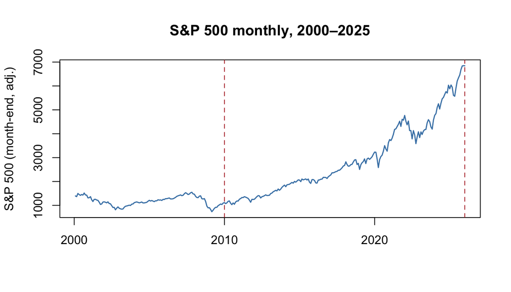

```r
plot(m$Date, m$SP500, type = "l", col = "steelblue", lwd = 1.5,
     xlab = "", ylab = "S&P 500 (month-end, adj.)",
     main = "S&P 500 monthly, 2000–2025")
abline(v = c(as.Date("2010-01-01"), as.Date("2025-12-31")), lty = 2, col = "firebrick")
```

# 12 Key takeaways

1. **Returns, not prices.** Returns are scale-free and (roughly) stationary; prices trend and are not.
2. **Two definitions, one idea.** Simple returns *multiply* across time and *add* across assets; log returns *add* across time and *approximately* add across assets. For daily data the two are almost interchangeable.
3. **Compounding → $e$.** Letting compounding frequency $\to\infty$ gives continuous compounding and the log return.
4. **Returns are not Normal.** Real equity returns show fat tails, mild negative skew, and volatility clustering; Jarque–Bera rejects normality for *every* series in our global sample. This motivates everything that follows in the course (GARCH, EVT, VaR).

*Reproduce everything here with `quarto render Day01_Supplement.qmd`. Swap the running example by changing the column name (`"SP500"`, `"AAPL"`, …) — the code is column-agnostic.*